# Components, Cliques, & Key Actors

SNA Learning Lab 3 Case Study

Dr. Shaun Kellogg

January 13, 2023

## 1. PREPARE

Our third SNA case study, *Components, Cliques, & Key Actors,* is inspired by the work of Jonathan Supovitz, Alan Daly, Miguel del Fresno and Christian Kolouch who examined the intense debate surrounding the Common Core State Standards education reform as it played out on Twitter. As noted on their expansive and interactive website for the [#COMMONCORE Project](https://www.hashtagcommoncore.com), the Common Core was a major education policy initiative of the early 21st century. A primary aim of the Common Core was to strengthen education systems across the United States through a set of specific and challenging education standards. Although these standards once enjoyed bipartisan support, we saw in our previous case study how these standards have become a political punching bag.

In our Text Mining Lab 2 case study, we examined public sentiment around the Common Core and Next Generation Science Standards. This analysis compliments that investigation by examining groups and central actors in networks that developed around tweets about the common core. Specifically, this case study will cover the following topics pertaining to each data-intensive workflow process:

1. **Prepare**: Prior to analysis, we’ll take a look at the context from which our data came, formulate some research questions, and get introduced the {tidygraph} and {ggraph} packages for analyzing relational data.
2. **Wrangle**: In the wrangling section of our case study, we will learn some basic techniques for manipulating, cleaning, transforming, and merging network data.
3. **Explore**: With our network data tidied, we learn to calculate some key measures for individuals in our network and illustrate key actors through network visualization.
4. **Model**: We conclude our analysis by introducing community detection algorithms for identifying groups and revisiting sentiment about the common core.
5. **Communicate**: Finally, we clean up our analysis create a polished data product to help communicate some key findings.

### 1a. Review the Research

Recall from [Social Network Analysis and Education: Theory, Methods & Applications](https://methods.sagepub.com/book/social-network-analysis-and-education) that the following four features used by Freeman (2004) to define the social network perspective:

1. Social network analysis is **motivated by a relational intuition** based on ties connecting social actors.
2. It is firmly **grounded in systematic empirical data**.
3. It **makes** **use of graphic imagery** to represent actors and their relations with one another.
4. It **relies** **on** **mathematical and/or computational models** to succinctly represent the complexity of social life.

The [#COMMONCORE Project](https://www.hashtagcommoncore.com) that we’ll examine next is an exemplary illustration of these four defining features of the social network perspective.

#### The #commoncore Project

[figure not shown]

Supovitz, J., Daly, A.J., del Fresno, M., & Kolouch, C. (2017). *#commoncore Project.* Retrieved from http://www.hashtagcommoncore.com.

#### Prologue

As noted by Supovitz et al. (2017), the Common Core State Standards have been a “persistent flashpoint in the debate over the direction of American education.” The #commoncore Project explores the Common Core debate on Twitter using a combination of social network analyses and psychological investigations which help to reveal both the underlying social structure of the conversation and the motivations of the participants.

The central question guiding this investigation was:

> How are social media-enabled social networks changing the discourse in American politics that produces and sustains education policy?

#### Data Sources & Analyses

The [methods page](https://www.hashtagcommoncore.com/project/methodology) of the #COMMONCORE Project provides a detailed discussion of the data and analyses used to arrive at the conclusions in *#commoncore: How social media is changing the politics of education*. Provided below is a summary of how authors retrieved data from Twitter and the analyses applied for each of the five acts in the website. I highly encourage you to take a look at this section if you’d like to learn more about their approach and in particular if you’re unfamiliar with how users can interact and communicate on Twitter.

#### Data Collection

To collect data on keywords related to the Common Core, the project used a customized data collection tool developed by two of our co-authors, Miguel del Fresno and Alan J. Daly, called *Social Runner Lab*. Similar to an approach we used in the Text Mining Lab 2 case study, [*Twitter Sentiment and School Reform*](https://sbkellogg.github.io/eci-588/unit-2/unit-2-walkthrough.html#2_WRANGLE), the authors downloaded data in real time directly from Twitter’s Application Programming Interface (API) based on tweets using specified keywords, keyphrases, or hashtags and then restricted their analysis to the following terms: *commoncore*, *ccss* and *stopcommoncore.* They also captured Twitter profile names, or user names, as well as the tweets, retweets, and mentions posted. Data included messages that are public on twitter, but not private direct messages between individuals, nor from accounts which users have made private.

#### Analyses

In order to address their research question, the authors applied social network analysis techniques in addition to qualitative and automated text mining approaches. For social network analyses, each node is an individual Twitter user (person, group, institution, etc.) and the connection between each node is the tweet, retweet, or mention/reply. After retrieving data from the Twitter API, the authors created a file that could be analyzed in Gephi, an open-source software program which depicts the relations as networks and provides metrics for describing features of the network.

In addition to data visualization and network descriptives, the authors examined group development and lexical tendencies among users. For group development, they used a community detection algorithm to identify and represent structural sub-communities, or “factions”, which they describe as a group with more ties within than across group even those group boundaries are somewhat porous). For lexical tendencies, the authors used the Linguistic Inquiry and Word Count (LIWC) lexicons to determine psychological drive, diagnose their level of conviction, make inferences about thinking styles, and even determine sentiment similar to what we examine in the Text Mining Lab 2 case study.

For a nice summary of the data used for the analysis, as well as the samples of actors and tweets, the keywords, and the methods that were utilized, see [Table 1. Data and Method for Each Act](https://www.hashtagcommoncore.com/project/methodology) in the Methods section of the #commoncore website.

#### **👉 Your Turn** **⤵**

For our SNA Lab 3 case study, we’ll apply some of the same techniques used by this study including calculating some basic network measures of centrality. For example, take a look at the [*Explore the Networks*](https://www.hashtagcommoncore.com/#2-1) section from Act 2: Central Actors and the Transmitters, Transceivers and Transcenders.

Click on each of the boxes for a select time period and in the space below list a couple Twitter users identified by their analysis as the following:

- **Transmitters:** YOUR RESPONSE HERE
- **Transceivers:** YOUR RESPONSE HERE
- **Transcenders:** YOUR RESPONSE HERE

Now visit Act 2 of the methods section and In the space below, identify the network measure used for the first two central actors (hint: it’s italicized) and copy their definition used. Note, Transcenders has been completed for you.

- *Transmitters* YOUR RESPONSE HERE
- *Transceivers* YOUR RESPONSE HERE
- *Transcenders* is measured by *degree* and consists of actors (i.e. Twitter uers) who have both high out-degree, as well as having high in-degree.

### 1b. Identify a Question(s)

Recall from above that the central question guiding the #COMMONCORE Project was:

> How are social media-enabled social networks changing the discourse in American politics that produces and sustains education policy?

For Unit 4, we are going to focus our questions on something a bit less ambitious but inspired by this work:

1. Who are the transmitters, transceivers, and transcenders in our Common Core Twitter network?
2. What subgroups, or factions, exist in our network?
3. Which actors in our network tend to be more opposed to the Common Core?

To address the last question, we’ll revisit our techniques we learned from our Unit 3 VADER sentiment analysis.

#### **👉 Your Turn** **⤵**

Based on what you know about networks and the context so far, what other research question(s) might ask we ask in this context that a social network perspective might be able to answer?

In the space below, type a brief response to the following questions:

- YOUR RESPONSE HERE

### 1c. Set Up Project

As highlighted in [Chapter 6 of Data Science in Education Using R](https://datascienceineducation.com/c06.html) (DSIEUR), one of the first steps of every workflow should be to set up your “Project” within RStudio. Recall that:

> A **Project** is the home for all of the files, images, reports, and code that are used in any given project

In the `network-analysis` GitHub repository you clonded, an RStudio Project has already been set up for you as indicated by the `.Rproj` file in your main directory in the Files pane. Got there and see if you can locate it.

#### Load Libraries

In Lab 1, we also learned about **packages**, or libraries, which are shareable collections of R code that can contain functions, data, and/or documentation and extend the functionality of R. You can always check to see which packages have already been installed and loaded into RStudio Cloud by looking at the the Files, Plots, & Packages Pane in the lower right hand corner.

#### **👉 Your Turn** **⤵**

First, load the following packages introduced in previous case studies and that we’ll be using again to wrangling and explore our data later sections:

- tidyverse
- igraph
- tidygraph
- ggraph
- skimr

```r
#YOUR CODE HERE
library(tidyverse)
```

```r
library(tidygraph)
library(ggraph)
library(skimr)
library(igraph)
```

## 2. WRANGLE

In general, data wrangling involves some combination of cleaning, reshaping, transforming, and merging data (Wickham and Grolemund 2016). As highlighted in Estrellado et al. (2020), wrangling network data can be even more challenging than other data sources since network data often includes variables about both individuals and their relationships.

For our data wrangling this week, we’re keeping it simple since working with relational data is a bit of a departure from our working with rectangular data frames. In this lab, we’ll revisit how to:

1. **Import Data**.
2. **Format Network Data**. We learn to shape our data files into two common formats for storing network data: edgelists and nodelists.
3. **Create a Network Object**. Finally, we’ll need to convert our data frames into special data format, an R network object, for working with relational data.

### 2a. Import Data

We’ll be using a data download from twitter that only includes relatively small set of tweets from one week to help keep things simple. Network graphs can quickly get unwieldy as the nodes in your network grow.

The #commoncore project does an excellent job visualizing large networks using advanced techniques. We’ll focus on a relatively small network since we’ll be introduce some very basic techniques for visualization.

```r
ccss_tweets <- read_csv("data/ccss-tweets-simple.csv")
```

### 2b. Format Network Data

Recall from Chapter 1 of Carolan (2014) that ties, or relations, are what connect actors to one another. These ties are often referred to as “edges” when formatting and graphing network data and the range of ties in a network can be extensive. Some of the more common ties, or edges, used to denote connections among actors in educational research include:

- Behavioral interaction (e.g., talking to each other or sending messages)
- Physical connection (e.g., sitting together at lunch, living in the same neighborhood)
- Association or affiliation (e.g., taking the same courses, belonging to the same peer group)
- Evaluation of one person by another (e.g., considering someone a friend or enemy)
- Formal relations (e.g., knowing who has authority over whom)
- Moving between places or status (e.g., school choice preferences, dating patterns among adolescents)

#### Create Edgelist

The **edgelist** format is slightly different than other formats you have likely worked with in that the values in the first two columns of each row represent a dyad, or tie between two nodes in a network. An edge-list can also contain other information regarding the strength, duration, or frequency of the relationship, sometime called weight, in addition to other “edge attributes.”

For our analysis of tweets in this case study, we’ll use an approach similar to that used by Supovitz et al. (2017). Specifically, each node is an individual Twitter user (person, group, institution, etc.) and the connection between each node is the tweet, retweet, or mention/reply.

#### **👉 Your Turn** **⤵**

Use the code chunk that follows, view the data we just imported using one of your favorite methods for inspecting data and answer the question that follows:

```r
#YOUR CODE HERE
view(ccss_tweets)
```

1. Which columns you think could be used to construct an edge list.
   - YOUR RESPONSE HERE

#### Extract Edges and Nodes

If one of the columns you indicated in your response above included `screen_name` nice work! You may also have noticed that the `mentions_screen_name` column includes the names of those in the reply column, as well as those “mentioned” in each tweet, i.e. whose username was included in a post.

As noted above, an edgelist includes the nodes that make up a tie or dyad. Since the only two columns we need to construct our edgelist is the `screen_name` of the tweet author and the screen names of those included in the mentions, let’s:

1. `relocate()` and rename those columns to `sender` and `target` to indicate the “direction” of the tweet;
2. `select()` those columns along with any attributes that we think might be useful for analysis later on, like the timestamp or content of the tweet, i.e. `text`;
3. assign our new data frame to `ties_1`.

```r
ties_1 <-  ccss_tweets %>%
  relocate(sender = screen_name, # rename scree_name to sender
           target = mentions_screen_name) %>% # rename to receiver
  select(sender,
         target,
         created_at,
         text)

ties_1
```

```
## # A tibble: 51 × 4
##    sender          target                              created_at          text
##    <chr>           <chr>                               <dttm>              <chr>
##  1 2bux15cents     <NA>                                2021-11-07 17:32:08 "At …
##  2 AlexiosAsText   MaggieEThornton                     2021-11-07 15:22:14 "@Ma…
##  3 tx_granny       BanjoTanJoe MillennialOther Richar… 2021-11-06 19:29:41 "@Mi…
##  4 PaprBagPrincss  <NA>                                2021-11-05 20:31:28 "#CC…
##  5 Tech4Learning   <NA>                                2021-11-05 18:01:00 "6 w…
##  6 listland        <NA>                                2021-11-05 12:30:40 "Top…
##  7 CapitolAdvocate <NA>                                2021-11-05 12:28:25 "\"I…
##  8 CapitolAdvocate MichaelPetrilli CapitolAdvocate     2021-10-31 11:56:22 "\"A…
##  9 BanjoTanJoe     MillennialOther Richard_Harambe Re… 2021-11-05 00:26:23 "@Mi…
## 10 MaendelWealth   4Patrick7 BookerSparticus           2021-11-04 13:16:29 "@4P…
## # … with 41 more rows
```

Our edgelist with attributes is almost ready, but we have a couple of issues we still need to deal with.

As you may have noticed, our receiver column contains the names of multiple Twitter users, but a dyad or tie can only be between two actors or nodes.

In order to place each target user in a separate row that corresponds with each sender of the tweet, we will need to “unnest” these names using the {tidytext} package from Unit 3.

#### The tidytext Package 📦

[figure not shown]

As we’ll learn first hand in this module, using tidy data principles can also make many text mining tasks easier, more effective, and consistent with tools already in wide use. The {tidytext} package helps to convert text into data frames of individual words, making it easy to to manipulate, summarize, and visualize text using using familiar functions form the {tidyverse} collection of packages.

Let’s go ahead and load the {tidytext} package:

```r
library(tidytext)
```

For a more comprehensive introduction to the `tidytext` package, I cannot recommend enough the free and excellent online book, *Text Mining with R: A Tidy Approach* (**silge2017text?**). If you’re interested in pursuing text analysis using R post Summer Workshop, this will be a go to reference.

#### “Unnest” User Names

The {tidy text} package has a very handy `unnest_tokens()` function to extract individual words from tweets. We’ll use it to place target of each tweet into separate rows corresponding to the sender of each tweet.

Run the following code and take a look at the new data frame to make sure it looks as expect and to spot any potential issues:

```r
ties_2 <- ties_1 %>%
  unnest_tokens(input = target,
                output = receiver,
                to_lower = FALSE) %>%
  relocate(sender, receiver)

ties_2
```

```
## # A tibble: 311 × 4
##    sender          receiver        created_at          text
##    <chr>           <chr>           <dttm>              <chr>
##  1 2bux15cents     <NA>            2021-11-07 17:32:08 "At what point will the …
##  2 AlexiosAsText   MaggieEThornton 2021-11-07 15:22:14 "@MaggieEThornton If eno…
##  3 tx_granny       BanjoTanJoe     2021-11-06 19:29:41 "@MillennialOther @Richa…
##  4 tx_granny       MillennialOther 2021-11-06 19:29:41 "@MillennialOther @Richa…
##  5 tx_granny       Richard_Harambe 2021-11-06 19:29:41 "@MillennialOther @Richa…
##  6 tx_granny       RepMikeJohnson  2021-11-06 19:29:41 "@MillennialOther @Richa…
##  7 PaprBagPrincss  <NA>            2021-11-05 20:31:28 "#CCChat (Common Core Ch…
##  8 Tech4Learning   <NA>            2021-11-05 18:01:00 "6 ways to incorporate d…
##  9 listland        <NA>            2021-11-05 12:30:40 "Top 10 Reasons Why Stan…
## 10 CapitolAdvocate <NA>            2021-11-05 12:28:25 "\"I’ve had students who…
## # … with 301 more rows
```

You probably notice one issue that we could deal with in a couple different ways. Specifically, many tweets are not directed at other users and hence the value for receiver is *`NA`*. We could keep these users as “isolates” in our network, but let’s simply remove them since our primary goal is to identify transmitters, transceivers and transcenders.

#### **👉 Your Turn** **⤵**

In the code chunk below, use the `drop_na()` function to remove the rows with missing values from our `receiver` column in our `ties-2` data frame since they are incomplete dyads. Save your final edgelist as `ties` using the `<-` assignment operator.

```r
#YOUR CODE HERE
ties <- ties_2 %>%
  drop_na(receiver)
```

Now use the code chunk below to take a quick look at our final edgelist and answer the questions that follow:

```r
ties
```

1. How many edges are in our CCSS network?
   - YOUR RESPONSE HERE
2. What do these ties/edges/connections represent?
   - YOUR RESPONSE HERE
3. When do they start and end?
   - YOUR RESPONSE HERE

Well done!!! Before moving on to the the nodes in our network, run the following code chunk to save our edgelist to a .csv file in our data folder for later use:

```r
write_csv(ties, "data/ccss-edgelist.csv")
```

#### Create Nodelist

The second file we need to create is a data frame that contains all the individuals in our network, often referred to as nodes or actors. This list sometimes includes attributes that we might want to examine as part of our analysis as well, like the number of Twitter followers, demographic group, country, gender, etc. This file or data frame is sometimes referred to as a **nodelist** or node attribute file.

To construct our basic nodelist, we will use the `pivot_longer()` function from the {dplyr} package, an updated version of the `gather()` function introduced in the [RStudio Reshape Data Primer](https://rstudio.cloud/learn/primers/4.1) shared in Foundations Learning Lab 3.

Run the following code to select the usernames form our `ties` edgelist, merge our sender and receiver columns into a single column, and take a quick look at our new data frame.

```r
actors_1 <- ties %>%
  select(sender, receiver) %>%
  pivot_longer(cols = c(sender,receiver))

actors_1
```

```
## # A tibble: 578 × 2
##    name     value
##    <chr>    <chr>
##  1 sender   AlexiosAsText
##  2 receiver MaggieEThornton
##  3 sender   tx_granny
##  4 receiver BanjoTanJoe
##  5 sender   tx_granny
##  6 receiver MillennialOther
##  7 sender   tx_granny
##  8 receiver Richard_Harambe
##  9 sender   tx_granny
## 10 receiver RepMikeJohnson
## # … with 568 more rows
```

As you can see, our sender and receiver usernames have been combined into a single column called `value` with a new column indicating whether they were a sender or receiver called `name` by default.

Since we’re only interested in usernames for our nodelist, and since we have a number of duplicate names, let’s select just the `value` column, rename it to actors, and use the `distinct()` function from {dplyr} to keep only unique names and remove duplicates:

```r
actors <- actors_1 %>%
  select(value) %>%
  rename(actors = value) %>%
  distinct()
```

#### **👉 Your Turn** **⤵**

Use the code chunk below to take a quick look at our final `actors` data frame and answer question that follows:

```r
#YOUR CODE HERE
actors
```

How many unique node/actors are in our CCSS network?

- YOUR RESPONSE HERE

Before we move on, save your nodelist to a .csv file in your data folder using the `write_csv()` function as we did above:

```r
#YOUR CODE HERE
write_csv(actors, "data/ccss-nodelist.csv")
```

### 2c. Create Network Object

Before we can begin using many of the functions from the {tidygraph} and {ggraph} packages for summarizing and visualizing our Common Core Twitter network, we first need to convert our node and edge lists into network object.

#### Combine Edges & Nodes

The {tidygraph} package contains a `tbl_graph()` function that includes the following arguments:

- `edges =` expects a data frame, in our case `ties`, containing information about the edges in the graph. The nodes of each edge must either be in a `to` and `from` column, or in the two first columns like the data frame we provided.
- `nodes =` expects a data frame, in our case `actors`, containing information about the nodes in the graph. If `to` and/or `from` are characters or names, like in our data frames, then they will be matched to the column named according to `node_key` in nodes, if it exists, or matched to the first column in the node list.
- `directed =` specifies whether the constructed graph should be directed, i.e. include information about whether each node is the sender or target of a connection. By default this is set to `TRUE`.

Let’s go ahead and create our network graph, name it `network` and print the output:

```r
ccss_network <- tbl_graph(edges = ties,
                          nodes = actors,
                          directed = TRUE)

ccss_network
```

```
## # A tbl_graph: 92 nodes and 289 edges
## #
## # A directed multigraph with 13 components
## #
## # Node Data: 92 × 1 (active)
##   actors
##   <chr>
## 1 AlexiosAsText
## 2 MaggieEThornton
## 3 tx_granny
## 4 BanjoTanJoe
## 5 MillennialOther
## 6 Richard_Harambe
## # … with 86 more rows
## #
## # Edge Data: 289 × 4
##    from    to created_at          text
##   <int> <int> <dttm>              <chr>
## 1     1     2 2021-11-07 15:22:14 @MaggieEThornton If enough were gathered coul…
## 2     3     4 2021-11-06 19:29:41 @MillennialOther @Richard_Harambe @RepMikeJoh…
## 3     3     5 2021-11-06 19:29:41 @MillennialOther @Richard_Harambe @RepMikeJoh…
## # … with 286 more rows
```

#### **👉 Your Turn** **⤵**

Take a look at the output for our simple graph above and answer the following questions:

1. Are the numbers and names of nodes and actors consistent with our `actors` and `ties` data frames? What about the integers included in the `from` and `to` columns of the Edge Data?
   - YOUR RESPONSE HERE
2. What do you think “components” refers to? **Hint:** see Chapter 6 of (Carolan 2014).
   - YOUR RESPONSE HERE
3. Is our network directed or undirected?
   - YOUR RESPONSE HERE

A quick note about “directed” networks. A **directed network** indicates that a connection or tie is not necessarily reciprocated or mutual. For example, our network is directed because even though a user may follow, mention or reply to someone else, they may not necessarily receive a follow, mention or reply back. A facebook friendship network is undirected, however, since someone can not “friend” someone on Facebook without them also indicating a “friend” relationship, so the friendship is mutual or reciprocated.

## 3. EXPLORE

As noted in the previous units, exploratory data analysis involves the processes of describing your network through mathematical measures and/or data visualization. In Section 3, we learn some new functions for identifying groups and subgroups and creating node-level measures to identify central actors in our network. Specifically, in this section we’ll focus on:

1. **Group Analysis**. We take a look at both a top-down and bottom-up approach to identifying groups within a network by examining the weak and strong components in our network as well as existing cliques.
2. **Egocentric Analysis**. We also examine the size of an ego’s “local neighborhood” as well as key centrality measures for each node such as degree, closeness, and betweenness.

### 3a. Group Analysis: Components, Cliques & Communities

#### Components

As noted in Social Network Analysis and Education (Carolan 2014), one of the most basic ways in which network researchers first characterize a network’s substructure is to identify its components.

> A **component** is a connected subgraph in which there is a path between all pairs of nodes.

Recall from our output above that our directed “multigraph” had 13 components. Let’s take a quick look at our network using the {tidygraph} `autograph()` function and see if we can spot the 13 components:

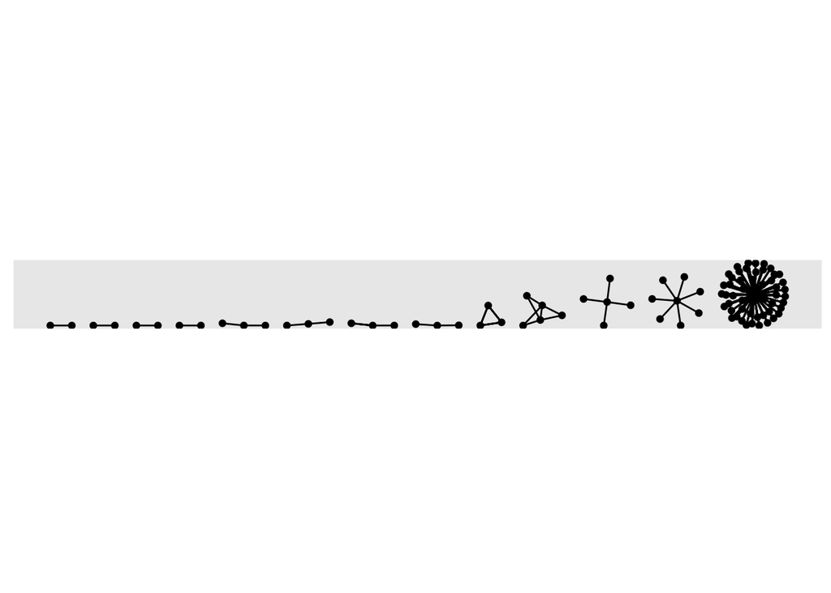

```r
autograph(ccss_network)
```

As you can see, the `autograph()` function arranges our components by their size, or number of actors.

Directed graphs, such as our CCSS twitter network, have two different kinds of components: weak and strong. A weak component, as illustrated above, ignores the direction of a tie; strong components do not. In other words:

> **Strong components** consist of nodes that are connected to one another via both directions along the path that connects them.

This concept of a component is simple and very useful, especially when analyzing a large network with many components. Often, researchers extract each component and analyze it as a separate network. We won’t be doing that here, but it would be very reasonable to remove the isolates from our network prior to further analysis.

The {igraph} package has a simple function for identifying the number of components in a network, the size of each component, and which actors belong to each. Let’s first take a quick look at the summaries for “weak” components in our network:

```r
components(ccss_network, mode = c("weak"))
```

```
## $membership
##  [1]  1  1  2  2  2  2  2  3  3  4  4  4  5  5  5  5  5  5  5  5  6  6  6  3  7
## [26]  7  8  8  8  8  8  9  9  9 10 10 10 11 11 11 11 11 11 11 11 11 11 11 11 11
## [51] 11 11 11 11 11 11 11 11 11 11 11 11 11 11 11 11 11 11 11 11 11 11 11 11 11
## [76] 11 11 11 11 11 11 11 11 11 11 11 11 11 12 12 13 13
##
## $csize
##  [1]  2  5  3  3  8  3  2  5  3  3 51  2  2
##
## $no
## [1] 13
```

While not incredibly intuitive to interpret, the output indicates that there are 13 components as we discovered above, 1 component has 51 members and the smallest components only have 2 members.

#### **👉 Your Turn** **⤵**

How do you think you might find the “strong” components in our network using the `component()` function? Use the following code chunk to test out your theory:

```r
# YOUR CODE HERE

components(ccss_network, mode = c("strong"))
```

```
## $membership
##  [1] 91 92 86 87 90 89 88 84 85 81 83 82 73 80 79 78 77 76 75 74 71 72 70 69 67
## [26] 68 62 66 65 64 63 59 61 60 56 57 58  5 55 54 53 52 51 50 49 48 47 46 45 44
## [51] 43 42 41 40 39 38 37 36 35 34 33 32 31 30 29 28 27 26 25 24 23 22 21 20 19
## [76] 18 17 16 15 14 13 12 11 10  9  8  7  6  3  4  1  2
##
## $csize
##  [1] 1 1 1 1 1 1 1 1 1 1 1 1 1 1 1 1 1 1 1 1 1 1 1 1 1 1 1 1 1 1 1 1 1 1 1 1 1 1
## [39] 1 1 1 1 1 1 1 1 1 1 1 1 1 1 1 1 1 1 1 1 1 1 1 1 1 1 1 1 1 1 1 1 1 1 1 1 1 1
## [77] 1 1 1 1 1 1 1 1 1 1 1 1 1 1 1 1
##
## $no
## [1] 92
```

Wow! If your code was correct, you’ll see that we have a whopping 92 distinct components!

One issue with this output that the {tidygraph} package is great at solving is identifying and saving as a new variable who belongs to which component. We can sort of see from above that the most twitter users in our network belong to component 11.

As demonstrated in the previous case study, the {tidygraph} package has a very useful `activate()` function for working with our nodes and edges as if they were standard “tibbles,” or [tidy data](https://cran.r-project.org/web/packages/tidyr/vignettes/tidy-data.html) tables.

Let’s use the `activate()` function to single out the node list in our network and use the familiar `mutate()` and [`group_components()`](https://tidygraph.data-imaginist.com/reference/group_graph.html) functions to create a new `weak_component` variable that indicates and saves the weak components to which each node belongs:

```r
ccss_network <- ccss_network |>
  activate(nodes) |>
  mutate(weak_component = group_components(type = "weak"))
```

Let’s take a look at the nodes in our new `ccss_network`, which should now contain our new variable.

```r
ccss_network
```

```
## # A tbl_graph: 92 nodes and 289 edges
## #
## # A directed multigraph with 13 components
## #
## # Node Data: 92 × 2 (active)
##   actors          weak_component
##   <chr>                    <int>
## 1 AlexiosAsText               10
## 2 MaggieEThornton             10
## 3 tx_granny                    3
## 4 BanjoTanJoe                  3
## 5 MillennialOther              3
## 6 Richard_Harambe              3
## # … with 86 more rows
## #
## # Edge Data: 289 × 4
##    from    to created_at          text
##   <int> <int> <dttm>              <chr>
## 1     1     2 2021-11-07 15:22:14 @MaggieEThornton If enough were gathered coul…
## 2     3     4 2021-11-06 19:29:41 @MillennialOther @Richard_Harambe @RepMikeJoh…
## 3     3     5 2021-11-06 19:29:41 @MillennialOther @Richard_Harambe @RepMikeJoh…
## # … with 286 more rows
```

We could also use another handy function from the {tidygraph} package, `as_tibble()`, that will temporarily convert our node list to a standard table that will allow us to view every row in our node list:

```r
as_tibble(ccss_network)
```

```
## # A tibble: 92 × 2
##    actors          weak_component
##    <chr>                    <int>
##  1 AlexiosAsText               10
##  2 MaggieEThornton             10
##  3 tx_granny                    3
##  4 BanjoTanJoe                  3
##  5 MillennialOther              3
##  6 Richard_Harambe              3
##  7 RepMikeJohnson               3
##  8 CapitolAdvocate              5
##  9 MichaelPetrilli              5
## 10 MaendelWealth                6
## # … with 82 more rows
```

```r
ccss_network |>
  as_tibble() |>
  group_by(weak_component) |>
  summarise(count = n()) |>
  arrange(desc(count))
```

```
## # A tibble: 13 × 2
##    weak_component count
##             <int> <int>
##  1              1    51
##  2              2     8
##  3              3     5
##  4              4     5
##  5              5     3
##  6              6     3
##  7              7     3
##  8              8     3
##  9              9     3
## 10             10     2
## 11             11     2
## 12             12     2
## 13             13     2
```

The `activate()` function from the {tidygraph} package is a powerful tool that let’s you leverage the entire suite of {tidyverse} packages to analyze nodes and edges in a network! We’ll be using the activate function again in section 3b. Egocentric Analysis: Size & Centrality to calculate node-level measures.

**Important Note:** In the code above, it’s important to take note when we have permanently altered our `ccss_network` object and when we have only made temporary changes to our network. For example, when creating a new variable for `weak_component`, we assigned the changes made to `ccss_network` to an object of the same name using the `<-` assignment operator. This effectively overwrites the old object with the new object because we wanted to save the new variable created. However, when converting network to a tibble consisting of nodes and their `weak_component` id, we did not assign to `ccss_network` because we did not want to permanently change to our network object to a rectangular data frame, or tibble in tidyverse speak.

#### **👉 Your Turn** **⤵**

Use the `activate()`, `mutate()` and [`group_components()`](https://tidygraph.data-imaginist.com/reference/group_graph.html) functions to create a new `strong_component` variable that indicates and saves the strong components to which each node belongs. Then create a summary table like above and answer the question that follows.

```r
ccss_network <- ccss_network |>
  activate(nodes) |>
  mutate(strong_component = group_components(type = "strong"))

ccss_network |>
  as_tibble() |>
  group_by(strong_component) |>
  summarise(count = n()) |>
  arrange(desc(count))
```

```
## # A tibble: 92 × 2
##    strong_component count
##               <int> <int>
##  1                1     1
##  2                2     1
##  3                3     1
##  4                4     1
##  5                5     1
##  6                6     1
##  7                7     1
##  8                8     1
##  9                9     1
## 10               10     1
## # … with 82 more rows
```

If you did this correctly, your analysis should be VERY revealing about the “conversation” around the common core based on this small sample of tweets.

1. Which strong component had the most members? Hint: this is a trick question.
   - YOUR RESPONSE HERE
2. What do you think this tells us about the conversation around the common core?
   - YOUR RESPONSE HERE

#### Cliques

Whereas top-down approaches to group analysis focus on the complete network and considers parts of it that distinct from the rest of the network, the bottom-up approach focuses is built up from simple dyads and triads that extend into dense clusters that give the network its “clumpiness.” Similar to complete network measures, there are several important properties for which precise definitions and algorithms have been developed, including cliques, clans, plexes, and cores (Carolan 2014).

Examining cliques is one bottom-up approach that reveals how groups are distributed in the network and which actors belong to which groups.

> A **clique** is a maximally connected subgraph of nodes (> 2) in which all nodes are connected to each other.

Similar to our component analysis, the {igraph} function has a simple `clique_num()` function for identifying number of completely connected subgroups in a network:

```r
clique_num(ccss_network)
```

```
## [1] 3
```

As you probably saw above, the `clique_num()` function does not take into account directionality of our ties. It looks like we have 3 clusters of at least 3 actors that all have ties to one another.

The {igraph} function also has a simple `cliques()` function for identifying members who belong to the same group. In addition to specifying the network you want to examine, this function also allows you to set the minimum and maximum number of members to included in a clique.

Let’s see if there are any cliques that contain a minimum of 4 nodes?

```r
cliques(ccss_network, min = 4, max = NULL)
```

```
## list()
```

#### Communities

Unfortunately, the {tidygraph} package does not have a clustering function for cliques. It does, however, include a range popular clustering functions provided that use range of functions that group nodes and edges based on “community structure.” Some of these [community detection algorithms](https://tidygraph.data-imaginist.com/reference/group_graph.html) are designed for directed graphs (e.g. our weak component analysis above), while others are for undirected graphs.

One community detection algorithm similar to our clique analysis above is the `group_edge_betweenness()` function, which groups densely connected nodes together. The betweenness centrality measures is something we will look at more closely in the next section.

Because this function can only be used with undirected networks, we will need to pipe `|>` our `dlt_network` through the following functions in sequence:

1. **`morph()`** with the `to_undirected` argument will temporarily change our directed network to an undirected network, or “symmetrize” our network as discussed in Carolan Carolan (2014);
2. **`activate()`** will select just our `nodes` list;
3. **`mutate()`** will created a new `subgroup` variable using the `group_edgebetweenness()` function;
4. **`unmorph()`** will change our undirected network back to a directed network.

Run the following code to group our nodes based on their edge betweenness and print our updated `ccss_network` object and take a quick look. Because this is a bit computationally intensive, it make take a minute or so to run.

```r
ccss_network <- ccss_network |>
  morph(to_undirected) |>
  activate(nodes) |>
  mutate(sub_group = group_edge_betweenness()) |>
  unmorph()

ccss_network |>
  as_tibble()
```

```
## # A tibble: 92 × 4
##    actors          weak_component strong_component sub_group
##    <chr>                    <int>            <int>     <int>
##  1 AlexiosAsText               10               91        10
##  2 MaggieEThornton             10               92        10
##  3 tx_granny                    3               86         3
##  4 BanjoTanJoe                  3               87         3
##  5 MillennialOther              3               90         3
##  6 Richard_Harambe              3               89         3
##  7 RepMikeJohnson               3               88         3
##  8 CapitolAdvocate              5               84         5
##  9 MichaelPetrilli              5               85         5
## 10 MaendelWealth                6               81         6
## # … with 82 more rows
```

As you scroll through the nodes tibble produced, you should now see at the far end a new `subgroup` variable that includes an ID number indicating to which densely connected cluster each node belongs.

Note, that if we had wanted to permanently convert our network to an undirected network, we could use the `to_undirected` argument as a stand-alone function.

```r
ccss_undirected <-  to_undirected(ccss_network)

ccss_undirected
```

```
## # A tbl_graph: 92 nodes and 289 edges
## #
## # An undirected multigraph with 13 components
## #
## # Node Data: 92 × 4 (active)
##   actors          weak_component strong_component sub_group
##   <chr>                    <int>            <int>     <int>
## 1 AlexiosAsText               10               91        10
## 2 MaggieEThornton             10               92        10
## 3 tx_granny                    3               86         3
## 4 BanjoTanJoe                  3               87         3
## 5 MillennialOther              3               90         3
## 6 Richard_Harambe              3               89         3
## # … with 86 more rows
## #
## # Edge Data: 289 × 4
##    from    to created_at          text
##   <int> <int> <dttm>              <chr>
## 1     1     2 2021-11-07 15:22:14 @MaggieEThornton If enough were gathered coul…
## 2     3     4 2021-11-06 19:29:41 @MillennialOther @Richard_Harambe @RepMikeJoh…
## 3     3     5 2021-11-06 19:29:41 @MillennialOther @Richard_Harambe @RepMikeJoh…
## # … with 286 more rows
```

Now let’s get a quick count of the number of members in each `sub_group`. Run the following code to group our nodes and print our new `ccss_network` object and take a quick look:

```r
ccss_network |>
  activate(nodes) |>
  as_tibble() |>
  group_by(sub_group) |>
  summarise(count = n()) |>
  arrange(desc(count))
```

```
## # A tibble: 13 × 2
##    sub_group count
##        <int> <int>
##  1         1    51
##  2         2     8
##  3         3     5
##  4         4     5
##  5         5     3
##  6         6     3
##  7         7     3
##  8         8     3
##  9         9     3
## 10        10     2
## 11        11     2
## 12        12     2
## 13        13     2
```

#### **👉 Your Turn** **⤵**

We’ve only scratched the surface of the range of top-down and bottom-up group analysis functions available in the {igraph} and {tidygraph} packages. In the code chunk below, try out one of the other grouping functions available in the [tidygraph](https://tidygraph.data-imaginist.com/reference/group_graph.html) or [igraph](https://igraph.org/r/html/latest/) packages to examine groups withing the `dlt1_network`:

```r
#YOUR CODE HERE
```

### 3b. Egocentric Analysis: Size & Centrality

In this section, we shift out analytical lens from groups to egos and the pattern of relations in which each individual is embedded. Implicit in egocentric analysis, and also very intuitive to understand, is that:

> An individual’s (**ego**) connections with others (**alters**) provides access to some instrumental (e.g., advice) or expressive (e.g., support) resource that may, in turn, be beneficial.

As summarized by Carolan Carolan (2014), the structure and content of these relations between an ego and a set of alters is the focus of egocentric network analysis. Since our research question aims to identify “key actors” in our network, we will look at two characteristics of an ego’s connections that are indicative their importance: size and centrality.

#### Size

Recall from our previous case study focused on complete network analysis, one simple and often ignored structural property of a social network is its size. This also applies to egocentric analysis.

> **Size** is simply the number of alters that are directly connected to ego.

This characteristic is also sometimes referred to as an ego’s **local neighborhood**, and as Carolan points out, size matters, because it indicates the amount of potential resources available in one’s network. For example, a student with a small friendship network may be at a disadvantage when it comes seeking support on schoolwork or advice on course or college enrollment.

We can use the same {tidygraph} process that we used for identifying groups and individual membership to calculate the size for each node. Specifically, we will need to `activate()` the `nodes` in our network and create a new variable which we’ll call `size` that is calculated using the `local_size()` function.

And since it’s much easier to inspect our data as a tibble than using the graph output, we’ll also convert our node to a table and `arrange()` in descending order by `size` to make it easier to see the range in values of our network:

```r
ccss_network <- ccss_network |>
  activate(nodes) |>
  mutate(size = local_size())

ccss_network |>
  as_tibble() |>
  arrange(desc(size)) |>
  select(actors, size)
```

```
## # A tibble: 92 × 2
##    actors           size
##    <chr>           <dbl>
##  1 rdsathene          51
##  2 waltduro            8
##  3 tx_granny           5
##  4 BanjoTanJoe         5
##  5 namaikatikura       5
##  6 MillennialOther     3
##  7 Richard_Harambe     3
##  8 RepMikeJohnson      3
##  9 CapitolAdvocate     3
## 10 MaendelWealth       3
## # … with 82 more rows
```

#### Centrality

As we learned in our previous case study and readings, a key structural property of networks is the concept of centralization. A network that is highly centralized is one in which relations are focused on a small number of actors or even a single actor in a network, whereas ties in a decentralized network are diffuse and spread over a number of actors.

**Degree**

One of the most common descriptives reported in network studies and a primary measure of centralization is degree.

> **Degree** is the number of ties to and from an ego. In a directed network, in-degree is the number of ties received, whereas out-degree is the number of ties sent.

The {tidygraph} package has an aptly named function `centrality_degree()` for calculating degree, in-degree, and out-degree for all actors in a network.

Run the following create two new variables for our nodes: `in_dgree` and `out_degree`. We’ll set the `mode =` argument in `centrality_degree()` function to `"in"` and `"out"` respectively.

```r
ccss_network <- ccss_network |>
  activate(nodes) |>
  mutate(in_degree = centrality_degree(mode = "in"),
         out_degree = centrality_degree(mode = "out"))

ccss_network |>
  as_tibble()
```

```
## # A tibble: 92 × 7
##    actors          weak_component strong_component sub_g…¹  size in_de…² out_d…³
##    <chr>                    <int>            <int>   <int> <dbl>   <dbl>   <dbl>
##  1 AlexiosAsText               10               91      10     2       0       1
##  2 MaggieEThornton             10               92      10     2       1       0
##  3 tx_granny                    3               86       3     5       0       4
##  4 BanjoTanJoe                  3               87       3     5       1       3
##  5 MillennialOther              3               90       3     3       2       0
##  6 Richard_Harambe              3               89       3     3       2       0
##  7 RepMikeJohnson               3               88       3     3       2       0
##  8 CapitolAdvocate              5               84       5     3       2       2
##  9 MichaelPetrilli              5               85       5     2       1       0
## 10 MaendelWealth                6               81       6     3       0       2
## # … with 82 more rows, and abbreviated variable names ¹sub_group, ²in_degree,
## #   ³out_degree
```

**A Quick Note about Multigraphs and Tie Strength**

Alternatively, we could “[simplify](https://igraph.org/r/doc/simplify.html)” our network by collapsing multiple edges between the same actors and assigning a value to edges between actors indicating tie strength. In this case it would be a measure of frequency of replies between actors. However, in the process of simplifying our network, we would lose important contextual information about the context of each tie, such as the when (timestamp) each tie was created.

Let’s dust off our [`ggplot()`](https://ggplot2-book.org/getting-started.html#basic-use) skills and take a look at the distribution of `in_degree`, or the number of replies or mentions a user has received, by using in `geom_histogram()` function for creating histograms.

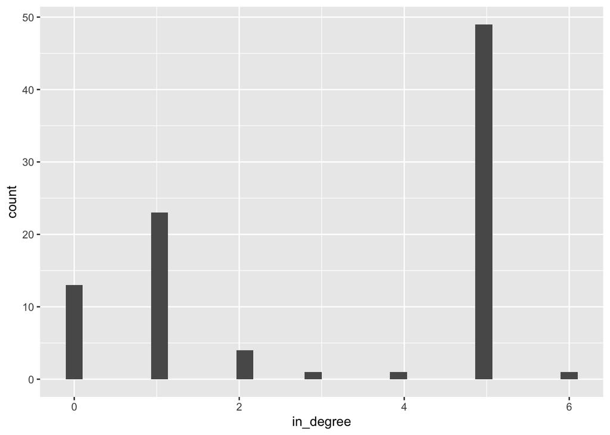

```r
ccss_network |>
  as_tibble() |>
  ggplot() +
  geom_histogram(aes(x = in_degree))
```

We can see that roughly half the egos in the network received about 5 replies or mentions from other users, and no one received more than 6 replies.

#### **Compositional and Variance Measures**

Carolan Carolan (2014) notes that there are two types of measures that can emerge from egocentric data: compositional and variance. Compositional measures are those created by counting or taking the average of egocentric network variables. Variance measures, on the other hand, are simply those that are derived by calculating the variance or standard deviation of the egocentric network variables.

While we could calculate invdividually the mean and variance for each egocentric measure created above using the `summarise()` function demonstrated earlier, R has a package and function to save us the effort.

To quickly calculate summary statistics for our nodes, including compositional and variance measures for our egocentric measures, we can use the `skim()` function from the {skimr} package to take a quick look at the variables in our node list:

```r
ccss_network |>
  as_tibble() |>
  skim()
```

Data summary

| Name | as_tibble(ccss_network) |
| --- | --- |
| Number of rows | 92 |
| Number of columns | 7 |
| _______________________ |  |
| Column type frequency: |  |
| character | 1 |
| numeric | 6 |
| ________________________ |  |
| Group variables | None |

**Variable type: character**

| skim_variable | n_missing | complete_rate | min | max | empty | n_unique | whitespace |
| --- | --- | --- | --- | --- | --- | --- | --- |
| actors | 0 | 1 | 3 | 15 | 0 | 92 | 0 |

**Variable type: numeric**

| skim_variable | n_missing | complete_rate | mean | sd | p0 | p25 | p50 | p75 | p100 | hist |
| --- | --- | --- | --- | --- | --- | --- | --- | --- | --- | --- |
| weak_component | 0 | 1 | 3.25 | 3.43 | 1 | 1.00 | 1.0 | 4.25 | 13 | ▇▁▁▁▁ |
| strong_component | 0 | 1 | 46.50 | 26.70 | 1 | 23.75 | 46.5 | 69.25 | 92 | ▇▇▇▇▇ |
| sub_group | 0 | 1 | 3.25 | 3.43 | 1 | 1.00 | 1.0 | 4.25 | 13 | ▇▁▁▁▁ |
| size | 0 | 1 | 2.80 | 5.15 | 2 | 2.00 | 2.0 | 2.00 | 51 | ▇▁▁▁▁ |
| in_degree | 0 | 1 | 3.14 | 2.14 | 0 | 1.00 | 5.0 | 5.00 | 6 | ▆▁▁▁▇ |
| out_degree | 0 | 1 | 3.14 | 25.63 | 0 | 0.00 | 0.0 | 0.00 | 246 | ▇▁▁▁▁ |

We can see, for example, that egos in our network are connected with on average just 2.8 alters. Notice also that our mean for in-degree and out-degree are identical. This will always be the case since for every tie that goes “in” there is always one going “out.”

Finally, the {skimr} package like our {tidgraph} package plays nicely with other {tidyverse} packages for data wrangling and analysis. For example, let’s select twitter users connected with fewer than 51 alters and `group_by()` their `weak_component` id to calculate compositional and variance measures for `size` for each component:

```r
ccss_network |>
  as_tibble() |>
  filter(size < 51) |>
  group_by(weak_component) |>
  select(size) |>
  skim()
```

Data summary

| Name | select(…) |
| --- | --- |
| Number of rows | 91 |
| Number of columns | 2 |
| _______________________ |  |
| Column type frequency: |  |
| numeric | 1 |
| ________________________ |  |
| Group variables | weak_component |

**Variable type: numeric**

| skim_variable | weak_component | n_missing | complete_rate | mean | sd | p0 | p25 | p50 | p75 | p100 | hist |
| --- | --- | --- | --- | --- | --- | --- | --- | --- | --- | --- | --- |
| size | 1 | 0 | 1 | 2.00 | 0.00 | 2 | 2 | 2 | 2.0 | 2 | ▁▁▇▁▁ |
| size | 2 | 0 | 1 | 2.75 | 2.12 | 2 | 2 | 2 | 2.0 | 8 | ▇▁▁▁▁ |
| size | 3 | 0 | 1 | 3.80 | 1.10 | 3 | 3 | 3 | 5.0 | 5 | ▇▁▁▁▅ |
| size | 4 | 0 | 1 | 2.60 | 1.34 | 2 | 2 | 2 | 2.0 | 5 | ▇▁▁▁▂ |
| size | 5 | 0 | 1 | 2.33 | 0.58 | 2 | 2 | 2 | 2.5 | 3 | ▇▁▁▁▃ |
| size | 6 | 0 | 1 | 2.33 | 0.58 | 2 | 2 | 2 | 2.5 | 3 | ▇▁▁▁▃ |
| size | 7 | 0 | 1 | 2.33 | 0.58 | 2 | 2 | 2 | 2.5 | 3 | ▇▁▁▁▃ |
| size | 8 | 0 | 1 | 2.33 | 0.58 | 2 | 2 | 2 | 2.5 | 3 | ▇▁▁▁▃ |
| size | 9 | 0 | 1 | 3.00 | 0.00 | 3 | 3 | 3 | 3.0 | 3 | ▁▁▇▁▁ |
| size | 10 | 0 | 1 | 2.00 | 0.00 | 2 | 2 | 2 | 2.0 | 2 | ▁▁▇▁▁ |
| size | 11 | 0 | 1 | 2.00 | 0.00 | 2 | 2 | 2 | 2.0 | 2 | ▁▁▇▁▁ |
| size | 12 | 0 | 1 | 2.00 | 0.00 | 2 | 2 | 2 | 2.0 | 2 | ▁▁▇▁▁ |
| size | 13 | 0 | 1 | 2.00 | 0.00 | 2 | 2 | 2 | 2.0 | 2 | ▁▁▇▁▁ |

**Closeness & Betweenness**

Two other centrality measures for identifying key actors in a network are closeness and betweenness. Whereas degree centrality is a local measure and can be calculated without needing information about the overall pattern of relations among ego and alters, closeness and betweenness address this shortcoming by taking into account indirect ties among all the alters in an ego’s network.

**Closeness** centrality captures the average distance an actor is from all other actors in the network and is a function of an actor’s geodesic distance to others, which equals the length of shortest path connecting a pair of actors. It’s an intuitively appealing measure in that being “close” to others may provide an advantage by giving you early access to new information or by indicating how quickly an actor can exchange something with others (Knoke & Yang, 2008).

**Betweenness** centrality measures the degree to which other actors lie on the shortest geodesic path between pairs of actors in the network. Betweenness may be indicative of how actors control or mediate the relations between pairs of actors that are not directly connected. Therefore, this measure is an important indicator of control over information exchange or resource flows within a network (Knoke & Yang, 2008). The more any given actor is located on the path between numerous dyads, the higher that actor’s potential to control network interactions. This concept and its associated measure is very appealing, as it captures the degree to which an actor occupies a strategically important position.

#### **👉 Your Turn** **⤵**

Use the code chunk below to add a `closeness` and `betweenness` variable to the nodes in our network and answer the questions that follow. **Hint**: you may want to look at the [functions to calculate node and edge centrality](https://tidygraph.data-imaginist.com/reference/centrality.html) on the {tidygraph} package website.

```r
# YOUR CODE HERE
ccss_network <- ccss_network |>
  activate(nodes) |>
  mutate(closeness = centrality_closeness(),
         betweenness = centrality_betweenness()) |>
  arrange(desc(betweenness))
ccss_network |>
  as_tibble()
```

```
## # A tibble: 92 × 9
##    actors          weak_…¹ stron…² sub_g…³  size in_de…⁴ out_d…⁵ close…⁶ betwe…⁷
##    <chr>             <int>   <int>   <int> <dbl>   <dbl>   <dbl>   <dbl>   <dbl>
##  1 CapitolAdvocate       5      84       5     3       2       2   1           1
##  2 AlexiosAsText        10      91      10     2       0       1   1           0
##  3 MaggieEThornton      10      92      10     2       1       0 NaN           0
##  4 tx_granny             3      86       3     5       0       4   0.25        0
##  5 BanjoTanJoe           3      87       3     5       1       3   0.333       0
##  6 MillennialOther       3      90       3     3       2       0 NaN           0
##  7 Richard_Harambe       3      89       3     3       2       0 NaN           0
##  8 RepMikeJohnson        3      88       3     3       2       0 NaN           0
##  9 MichaelPetrilli       5      85       5     2       1       0 NaN           0
## 10 MaendelWealth         6      81       6     3       0       2   0.5         0
## # … with 82 more rows, and abbreviated variable names ¹weak_component,
## #   ²strong_component, ³sub_group, ⁴in_degree, ⁵out_degree, ⁶closeness,
## #   ⁷betweenness
```

Again, we’ve only scratched the surface of the vast number of centrality meaures available in the {igraph} and {tidygraph} packages. Feel free to explore [other functions to calculate node and edge centrality](https://tidygraph.data-imaginist.com/reference/centrality.html) in these two packages.

### 3c. Visualize Network Descriptives

If you recall from 1a. Review the Research section, one of the defining characteristics of the social network perspective is its use of graphic imagery to represent actors and their relations with one another. To emphasize this point, Carolan (2014) reported that:

> The visualization of social networks has been a core practice since its foundation more than 90 years ago and remains a hallmark of contemporary social network analysis.

#### Create a Simple Sociogram

Recall from previous labs that building a network viz with {ggraph} is intentionally very much like building a standard graph with `ggplot()`, R’s most popular package for data visualization.

Also recall that the `ggraph()`, `geom_node_*()`, and `geom_edge*()` functions are the three basic, but very powerful functions, required to create a simple sociogram. Respectively, these three functions takes care of setting up the graph layout and “adding” the nodes and edges to the sociogram using the `+` operator.

#### **👉 Your Turn** **⤵**

Use the `ggraph()` function with Fruchterman-Reingold (FR) layout and add the `geom_node_point()` and `geom_edge_link()` functions to create a simple sociogram:

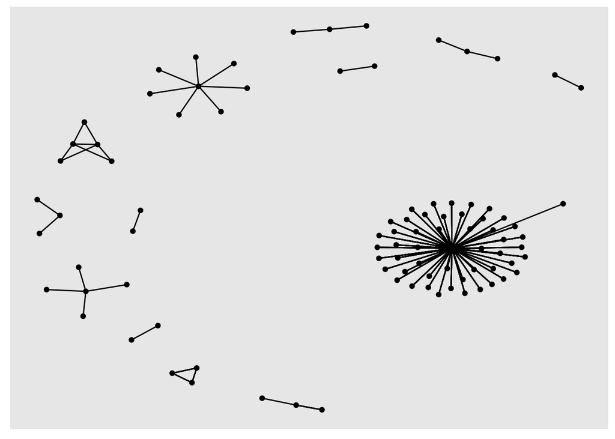

```r
#YOUR CODE HERE
ggraph(ccss_network, layout = "fr") +
  geom_node_point() +
  geom_edge_link()
```

#### Add Node Degree

Recall from prior labs that like {ggplot2}, geoms can include aesthetics, or aes for short, such as `alpha` for transparency, as well as `color`, `shape` and `size`.

Let’s included the `aes()` function and arguments such as `size =` and `color =`, which we can set to our `out_degree`, and also add our `theme_graph()` layer introduced in previous labs to help highlight our primary “transmitters”:

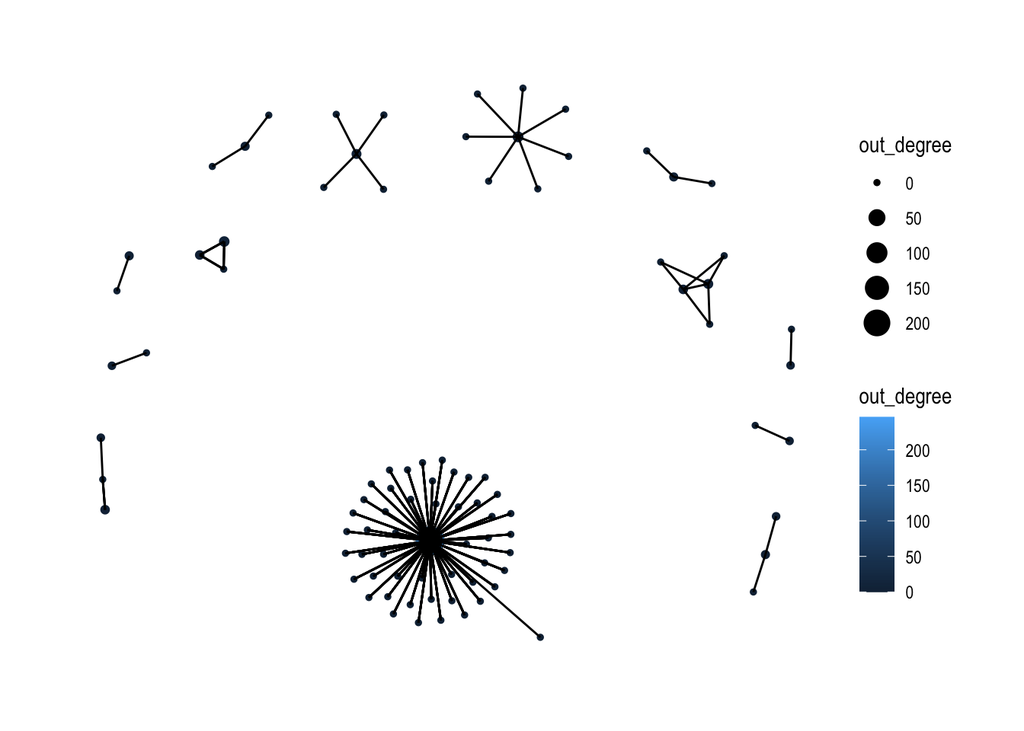

```r
ggraph(ccss_network, layout = "fr") +
geom_node_point(aes(size = out_degree,
                    color = out_degree)) +
  geom_edge_link() +
  theme_graph()
```

Let’s add another layer with some node text and labels. Since node labels are a geometric element, we can apply aesthetics to them as well, like color and size. Let’s also include the `repel =` argument that when set to `TRUE` will avoid overlapping text.

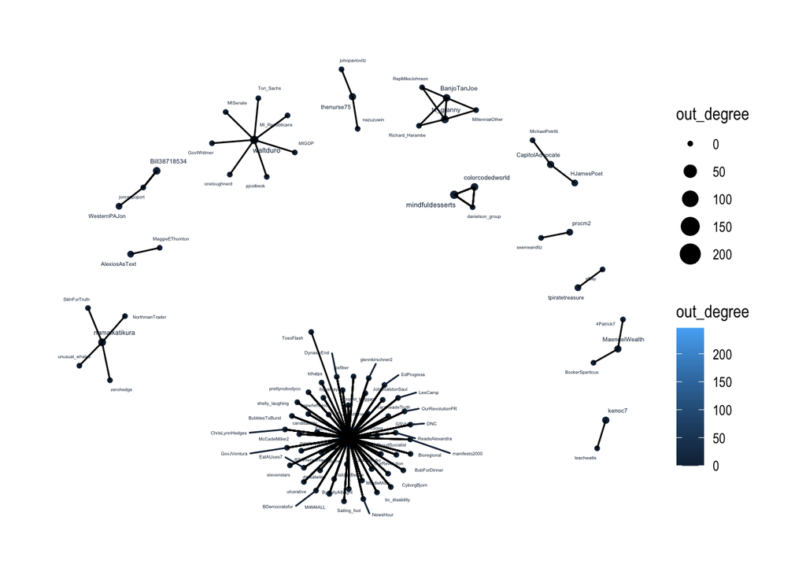

```r
ggraph(ccss_network, layout = "fr") +
  geom_node_point(aes(size = out_degree,
                      color = out_degree)) +
  geom_node_text(aes(label = actors,
                     size = out_degree/2,
                     color = out_degree),
                 repel=TRUE) +
  geom_edge_link() +
    theme_graph()
```

**Note:** If you’re having difficulty seeing the sociogram in the small R Markdown code chunk, you can copy and paste the code in the console and it will show in the viewpane and then you can enlarge and even save as an image file.

#### Modify Edges

Now, let’s include some arguments like `arrow =` to include some arrows 1mm in length, an `end_cap =` around each node to keep arrows from overlapping the them, and set the transparency of our edges to `alpha = .2` so our edges fade more into the background and help keep the focus on our nodes:

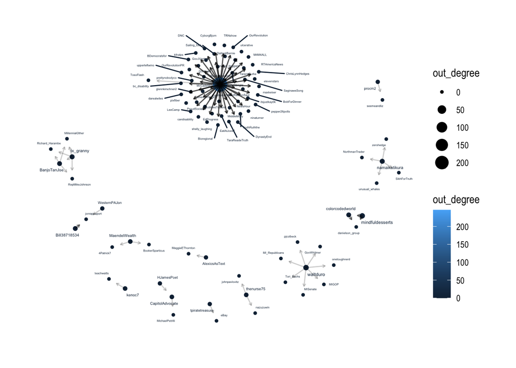

```r
ggraph(ccss_network, layout = "fr") +
  geom_node_point(aes(size = out_degree,
                      color = out_degree)) +
  geom_node_text(aes(label = actors,
                     size = out_degree/2,
                     color = out_degree),
                 repel=TRUE) +
  geom_edge_link(arrow = arrow(length = unit(1, 'mm')),
                 end_cap = circle(3, 'mm'),
                 alpha = .2) +
    theme_graph()
```

#### **👉 Your Turn** **⤵**

Try modifying the code below by tweaking the included function/arguments or adding new ones for [layouts](https://ggraph.data-imaginist.com/articles/Layouts.html), [nodes](https://ggraph.data-imaginist.com/articles/Nodes.html), and [edges](https://ggraph.data-imaginist.com/articles/Edges.html) to highlight the main “transenders” or “tranceivers” in our network. See if you can also make your plot either more “aesthetically pleasing” and/or more purposeful in what it’s trying to communicate.

There are no right or wrong answers, just have some fun trying out different approaches!

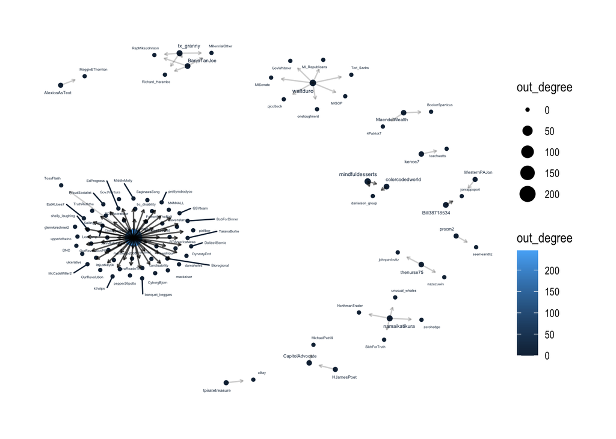

```r
#YOUR CODE HERE
ggraph(ccss_network, layout = "fr") +
  geom_node_point(aes(size = out_degree,
                      color = out_degree)) +
  geom_node_text(aes(label = actors,
                     size = out_degree/2,
                     color = out_degree),
                 repel=TRUE) +
  geom_edge_link(arrow = arrow(length = unit(1, 'mm')),
                 end_cap = circle(3, 'mm'),
                 alpha = .2) +
    theme_graph()
```

#### Alternate Graph Representations

The {tidygraph} package has a wide range of [functions to generate alternate representations of graphs](https://tidygraph.data-imaginist.com/reference/morphers.html). They can be used as stand alone functions to permanently alter your network, or as an argument with the `morph()` function to temporarily change your network depending on the analyses you need to perform.

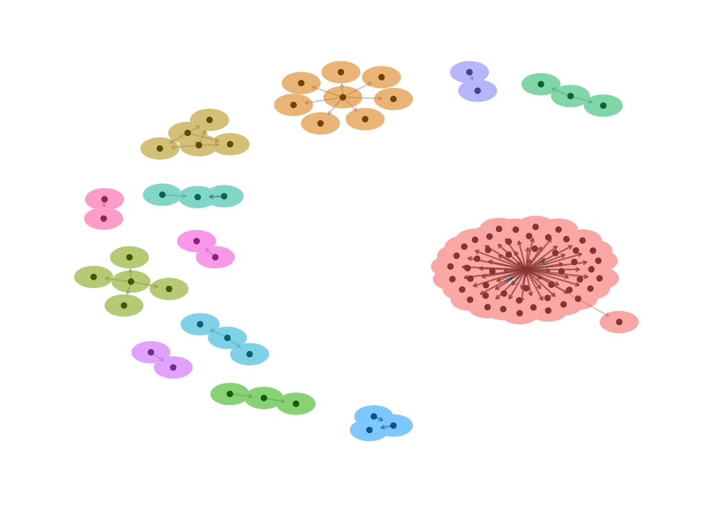

```r
ccss_network |>
  ggraph(layout = "fr") +
  geom_node_point() +
  geom_edge_link(arrow = arrow(length = unit(1, 'mm')),
                 end_cap = circle(3, 'mm'),
                 alpha = .2) +
  theme_graph() +
  geom_node_voronoi(aes(fill = factor(sub_group),
                         alpha = .05),
                    max.radius = .5,
                    show.legend = FALSE)
```

This clearly does not provide any much insight, nor is it any improvement to our previous sociogram, but it definitely is colorful!!

## 4. MODEL

As highlighted in [Chapter 3 of Data Science in Education Using R](https://datascienceineducation.com/c03.html), the **Model** step of the data science process entails “using statistical models, from simple to complex, to understand trends and patterns in the data.” The authors note that while descriptive statistics and data visualization during the **Explore** step can help us to identify patterns and relationships in our data, statistical models can be used to help us determine if relationships, patterns and trends are actually meaningful.

### 4a. Sentiment Analysis (Optional)

We will not explore the use of statistical inference and models for social networks until Learning Lab 4, but take a look at [The Mood of the Common Core Factions](https://www.hashtagcommoncore.com/#4-2) section from the #COMMONCORE project. Sentiment analysis is a common text mining technique that tries to evaluate words for their emotional association, or even “mood”, similar to the approached used by the #COMMONCORE project.

The tidytext package we tapped into earlier provides access to several sentiment lexicons for text analysis based on unigrams, i.e., single words. These lexicons contain many English words and the words are assigned scores for positive/negative sentiment, and also possibly emotions like joy, anger, sadness, and so forth. However, the {vader} package provides a relatively easy entry into modeling positive and negative tweet sentiment.

#### The vader Package 📦

[figure not shown]

The {vader} package is for the Valence Aware Dictionary for sEntiment Reasoning (VADER), a rule-based model for general sentiment analysis of social media text and specifically attuned to measuring sentiment in microblog-like contexts.

To learn more about the {vader} package and its development, take a look at the article by Hutto and Gilbert (2014), [VADER: A Parsimonious Rule-based Model forSentiment Analysis of Social Media Text](http://comp.social.gatech.edu/papers/icwsm14.vader.hutto.pdf).

Let’s go ahead and load the VADER library:

```r
library(vader)
```

**Note:** The {vader} package can take quite some time to run on a large dataset like ours so it’s included in our R-each section for you to explore at your leisure. The example show in the reach section includes just a small(ish) subset of tweets for demonstration purposes.

#### Come to the Dark Side

[figure not shown]

Unlike other approaches demonstrated in the Text Mining Learning Lab 2, which assign sentiment to each individual word in a corpus of tweets, the VADER assigns a number of different sentiment measures based on the context of the entire social-media post or in our case a tweet. This saves quite a bit of data wrangling allowing us to work with our tweets in their original format.

VADER basically has just one function, `vader_df()` that does one thing and expects just one column from one frame. He’s very single minded! Let’s give VADER our `ccss_tweets` data frame we created in the beginning of this case study and include the `$` operator to include only the `text` column containing our tweets.

```r
vader_ccss <- vader_df(ccss_tweets$text)

vader_ccss
```

[output not shown]

[output cut: 141 more lines]

Does it generally seem accurately identify positive and negative tweets? Could you find any that you think were mislabeled?

- YOUR RESPONSE HERE

Hutto, C. & Gilbert, E. (2014) provide an excellent summary of the VADER package on their GitHub repository and I’ve copied and explanation of the scores below:

- The `compound` score is computed by summing the valence scores of each word in the lexicon, adjusted according to the rules, and then normalized to be between -1 (most extreme negative) and +1 (most extreme positive). This is the most useful metric if you want a single unidimensional measure of sentiment for a given sentence. Calling it a ‘normalized, weighted composite score’ is accurate.

**NOTE:** The `compound` score is the one most commonly used for sentiment analysis by most researchers, including the authors.

Let’s take a look at the average compound score for our CCSS sample of tweets:

```r
mean(vader_ccss$compound)
```

```
## [1] 0.1506471
```

Overall, does your CCSS tweets sample lean slightly negative or positive? Is this what you expected?

What if we wanted to compare these results more easily to our other sentiment lexicons just to check if result are fairly consistent?

The author’s note that it is also useful for researchers who would like to set standardized thresholds for classifying sentences as either positive, neutral, or negative. Typical threshold values are:

- **positive sentiment**: `compound` score >= 0.05
- **neutral sentiment**: (`compound` score > -0.05) and (`compound` score < 0.05)
- **negative sentiment**: `compound` score <= -0.05

Let’s give that a try and see how things shake out:

```r
vader_ccss_summary <- vader_ccss %>%
  mutate(sentiment = ifelse(compound >= 0.05, "positive",
                            ifelse(compound <= -0.05, "negative", "neutral"))) %>%
  count(sentiment, sort = TRUE) %>%
  spread(sentiment, n) %>%
  relocate(positive) %>%
  mutate(ratio = negative/positive)

vader_ccss_summary
```

```
##   positive negative neutral     ratio
## 1       28       12      11 0.4285714
```

Not quite as bleak as we might have expected according to VADER! But then again, VADER brings an entirely different perspective coming from the dark side.

#### **👉 Your Turn** **⤵**

Use the code chunk below to see if you can identify the “haters” in our network merging the sentiment scores results stored in our `vader_ccss` data frame with our original `ccss_tweets` data frame. **Hint:** you may need to use a `join_()` function.

```r
# YOUR CODE HERE
```

1. Who were the most negative twitter users in our network?
   - YOUR RESPONSE HERE

## 5. COMMUNICATE

The final step in our workflow/process is sharing the results of our analysis with wider audience. Krumm et al. (2018) have outlined the following 3-step process for communicating with education stakeholders findings from an analysis:

1. **Select.** Communicating what one has learned involves selecting among those analyses that are most important and most useful to an intended audience, as well as selecting a form for displaying that information, such as a graph or table in static or interactive form, i.e. a “data product.”
2. **Polish**. After creating initial versions of data products, research teams often spend time refining or polishing them, by adding or editing titles, labels, and notations and by working with colors and shapes to highlight key points.
3. **Narrate.** Writing a narrative to accompany the data products involves, at a minimum, pairing a data product with its related research question, describing how best to interpret the data product, and explaining the ways in which the data product helps answer the research question.

### 👉 Your Turn ⤵

For your final Your Turn, your goal is to distill our analysis from above into a simple “data product” designed to illustrate key findings about changes in the collaboration network over time. For the purposes of this task, imagine that your audience consists of colleagues with limited background in SNA and adapt the following steps accordingly:

1. **Select.** Select a group analysis of 1-2 node-level measures that you think would be interesting or relevant for your target audience and that help answer our research questions.
2. **Polish.** Create and polish a data visualization and/or data table to communicate your selected findings.
3. **Narrate.** Write a brief narrative (2-3 paragraphs) to accompany your visualization and/or table that includes the following:
   - The question or questions are guiding your analysis;
   - The conclusions you’ve reached based on your analyses and findings;
   - How your audience might use this information;
   - How you might revisit or improve upon this analysis in the future.

Use the code chunk below create a polished table or visualization(s) and write a brief narrative in the space that follows.

#### Data Visualization or Table

```r
# YOUR CODE HERE
```

### 🧶 Knit & Check ✅

Congratulations - you’ve completed the Lab 4 case study! One final step is to “Knit” your document by clicking the drop down arrow next to the ball of yarn in the menu bar an that the top of this markdown file, and then selecting “Knit top HTML” or another preferred output format. This will do two things: 1) it will check through all your code for any errors, 2) it will created a file in your directory that you can use to share you work through [GitHub Pages](https://pages.github.com), [RPubs](https://rpubs.com/about/getting-started), or any other preferred means.

Carolan, Brian. 2014. “Social Network Analysis and Education: Theory, Methods & Applications.” https://doi.org/10.4135/9781452270104.

Estrellado, Ryan A., Emily A. Freer, Jesse Mostipak, Joshua M. Rosenberg, and Isabella C. Velásquez. 2020. *Data Science in Education Using r*. Routledge. https://doi.org/10.4324/9780367822842.

Supovitz, Jonathan, Alan J Daly, Miguel del Fresno, and Christian Kolouch. 2017. “Commoncore Project.” *Retrieved April* 3: 2019. http://www.hashtagcommoncore.com/.

Wickham, Hadley, and Garrett Grolemund. 2016. *R for Data Science: Import, Tidy, Transform, Visualize, and Model Data*. " O’Reilly Media, Inc.". https://r4ds.had.co.nz.